# Laboratorio 2

Author

Cristina Chavez

Published

January 9, 2027

## Librerías necesarias

```python
import pandas as pd
import re
import numpy as np

import seaborn as sns
import matplotlib.pyplot as plt

from sklearn.model_selection import train_test_split
from sklearn.preprocessing import OneHotEncoder, StandardScaler
from sklearn.compose import ColumnTransformer
from sklearn.pipeline import Pipeline
from sklearn.ensemble import RandomForestClassifier
from sklearn.metrics import classification_report, confusion_matrix
```

## Importar los datos

```python
url = "https://raw.githubusercontent.com/erickedu85/dataset/refs/heads/master/tweets/tweets_totales_con_sentimiento_ml.csv"
```

```python
df = pd.read_csv(url)
df.head()
```

|  | tweetId | tweetUrl | content | isReply | replyTo | createdAt | authorId | authorName | authorUsername | authorVerified | ... | conversationId | inReplyToId | Date | time_response | account_age_days | mentions_count | hashtags_count | content_length | has_profile_picture | sentiment_polarity |
| --- | --- | --- | --- | --- | --- | --- | --- | --- | --- | --- | --- | --- | --- | --- | --- | --- | --- | --- | --- | --- | --- |
| 0 | 1877190873579950336 | https://x.com/hectorjalonm/status/187719087357... | @DiegoPonguill10 @DanielNoboaOk @LuisaGonzalez... | True | DiegoPonguill10 | 2025-01-09 03:09:00 | 1458536175119986688 | héctor 🌵 | hectorjalonm | False | ... | 1877115691146306005 | 1877188297551650816 | 2025-01-08 22:10:30 | 298.5 | 1151 | 3 | 0 | 88 | True | 0.0 |
| 1 | 1877188297551650816 | https://x.com/DiegoPonguill10/status/187718829... | @hectorjalonm @DanielNoboaOk @LuisaGonzalezEc ... | True | hectorjalonm | 2025-01-09 02:59:00 | 1555549203211976704 | Diego Ponguillo Vargas TODO TODITO #5 😉 HLVS!! | DiegoPonguill10 | False | ... | 1877115691146306005 | 1877123519743451648 | 2025-01-08 22:10:30 | 288.5 | 883 | 3 | 0 | 119 | True | 0.0 |
| 2 | 1877186248986501120 | https://x.com/ekuador_593/status/1877186248986... | @Gregori58965636 @yesendiaz @DanielNoboaOk Otr... | True | Gregori58965636 | 2025-01-09 02:50:00 | 1457524470365708288 | Sebastián Noboa Ec | ekuador_593 | False | ... | 1877115691146306005 | 1877122565782576896 | 2025-01-08 22:10:30 | 279.5 | 1153 | 3 | 0 | 60 | True | 0.0 |
| 3 | 1877168335193833472 | https://x.com/JRamirez2O24/status/187716833519... | @jdiegol2010 @DanielNoboaOk https://t.co/CsLWQ... | True | jdiegol2010 | 2025-01-09 01:39:00 | 1759130630766341888 | ANDRES RAMIREZ | JRamirez2O24 | False | ... | 1877115691146306005 | 1877159202646315264 | 2025-01-08 22:10:30 | 208.5 | 321 | 2 | 0 | 51 | True | 0.0 |
| 4 | 1877159202646315264 | https://x.com/jdiegol2010/status/1877159202646... | @JRamirez2O24 @DanielNoboaOk El tema es respet... | True | JRamirez2O24 | 2025-01-09 01:03:00 | 146111157 | Juan Diego | jdiegol2010 | False | ... | 1877115691146306005 | 1877130145938481152 | 2025-01-08 22:10:30 | 172.5 | 5343 | 2 | 0 | 80 | True | 0.0 |

5 rows × 26 columns

En lo personal, .info() siento que me brinda información un poco más relevante

```python
df.info()
```

```
<class 'pandas.core.frame.DataFrame'>
RangeIndex: 158873 entries, 0 to 158872
Data columns (total 26 columns):
 #   Column               Non-Null Count   Dtype
---  ------               --------------   -----
 0   tweetId              158873 non-null  int64
 1   tweetUrl             158873 non-null  object
 2   content              158873 non-null  object
 3   isReply              158873 non-null  bool
 4   replyTo              158011 non-null  object
 5   createdAt            158873 non-null  object
 6   authorId             158873 non-null  int64
 7   authorName           158871 non-null  object
 8   authorUsername       158873 non-null  object
 9   authorVerified       158873 non-null  bool
```

[output cut: 18 more lines]

### Qué puedo decir de esto.

¿Me interesan las menciones y los hastags?

- Me sirven las columnas: – Content. Debe ser la base del análisis. – isReply. Si es que el twit tuvo impacto – createdAt. En que momento habían más twits, mientras más nos acercabamos a las elecciones. – authorVerified. Probabilidades de que el perfil no sea un boot. – time_response. Puedo ver cuanto tiempo se demoran escribiendo un Twit, según la cantidad de caracteres. – account_age_days. Puedo medir la confianza del twit con el tiempo de vida de la cuenta – Content_length. el largo del twit –has_profile_picture. Tiene foto de perfil, puede ser probable que sea confiable. – sentiment_polarity. Feliz, triste.

```python
df = df.drop(df.columns[[0, 1, 4, 6, 7, 8, 10, 11, 12, 13, 16, 17, 18, 21, 22]], axis=1)

df.info()
```

```
<class 'pandas.core.frame.DataFrame'>
RangeIndex: 158873 entries, 0 to 158872
Data columns (total 11 columns):
 #   Column               Non-Null Count   Dtype
---  ------               --------------   -----
 0   content              158873 non-null  object
 1   isReply              158873 non-null  bool
 2   createdAt            158873 non-null  object
 3   authorVerified       158873 non-null  bool
 4   hashtags             12415 non-null   object
 5   mentions             158525 non-null  object
 6   time_response        158873 non-null  float64
 7   account_age_days     158873 non-null  int64
 8   content_length       158873 non-null  int64
 9   has_profile_picture  158873 non-null  bool
 10  sentiment_polarity   158873 non-null  float64
dtypes: bool(3), float64(2), int64(2), object(4)
memory usage: 10.2+ MB
```

## Y el target?

En este dataset podemos aprovechar la información sobre la polaridad del sentimiento.

Idea: Podríamos definir etiquetas pro_luisa o pro_daniel, si asumimos que un @luis con sentimiento positivo es pro luisa, y lo contrario, pro_daniel

**Por ahora lo que podemos hacer es aprovechar el target del sentimiento** porque de alguna y ver como influyen las variables que consideré importantes.

### El target como categorías:

```python
df['sentiment_label'] = np.select(
    [
        df['sentiment_polarity'] > 0,
        df['sentiment_polarity'] < 0
    ],
    ['positivo', 'negativo'],
    default='neutro'
)

# Ver la distribución de clases
df['sentiment_label'].value_counts()
```

```
sentiment_label
neutro      152896
negativo      3481
positivo      2496
Name: count, dtype: int64
```

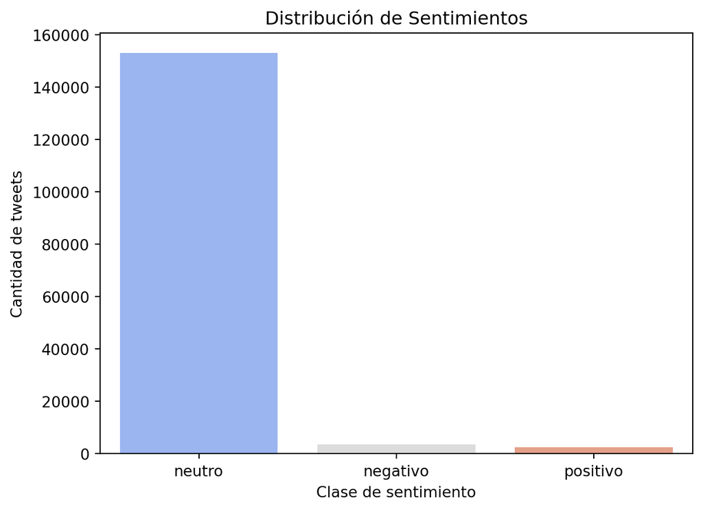

```python
sns.countplot(data=df, x='sentiment_label', palette='coolwarm',
              order=df['sentiment_label'].value_counts().index)
plt.title('Distribución de Sentimientos')
plt.xlabel('Clase de sentimiento')
plt.ylabel('Cantidad de tweets')
plt.show()
```

**El dataset con los valores de sentimiento esta más de desvalanceado, elegimos otro camino*

Elimino la columna de analisis sentimental, porque no considero util.

```python
df = df.drop(df.columns[[0, 2, 4,5, 10]], axis=1)

df.info()
```

```
<class 'pandas.core.frame.DataFrame'>
RangeIndex: 158873 entries, 0 to 158872
Data columns (total 7 columns):
 #   Column               Non-Null Count   Dtype
---  ------               --------------   -----
 0   isReply              158873 non-null  bool
 1   authorVerified       158873 non-null  bool
 2   time_response        158873 non-null  float64
 3   account_age_days     158873 non-null  int64
 4   content_length       158873 non-null  int64
 5   has_profile_picture  158873 non-null  bool
 6   sentiment_label      158873 non-null  object
dtypes: bool(3), float64(1), int64(2), object(1)
memory usage: 5.3+ MB
```

### Solución.

```python
# Crear etiqueta "bot" según condiciones heurísticas
df['bot_label'] = (
    (df['account_age_days'] < 500) &
    (df['time_response'] < 800)
).astype(int)

# Revisar distribución
print(df['bot_label'].value_counts())
```

```
bot_label
0    136710
1     22163
Name: count, dtype: int64
```

Verificación visual

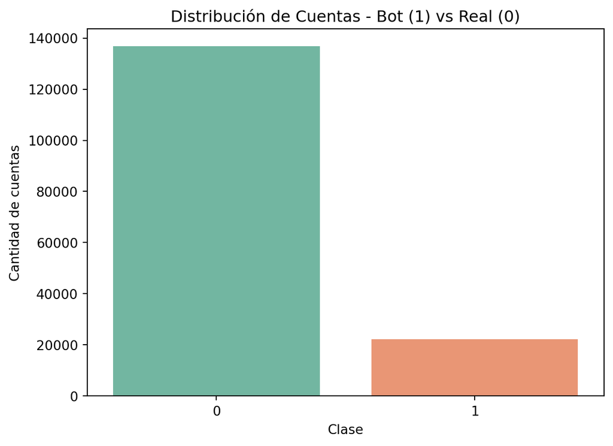

```python
sns.countplot(data=df, x='bot_label', palette='Set2')
plt.title('Distribución de Cuentas - Bot (1) vs Real (0)')
plt.xlabel('Clase')
plt.ylabel('Cantidad de cuentas')
plt.show()
```

```python
df['time_response'].describe()
```

```
count    158873.000000
mean       1152.408043
std        3303.138599
min          -0.550000
25%         122.883333
50%         484.550000
75%        1298.716667
max      138292.933333
Name: time_response, dtype: float64
```

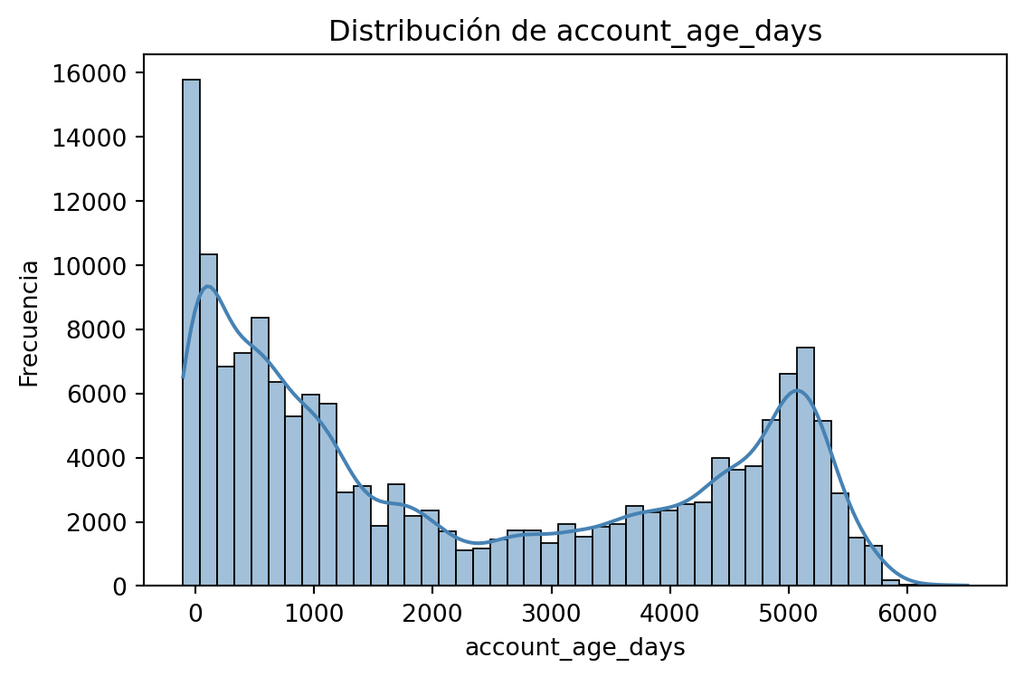

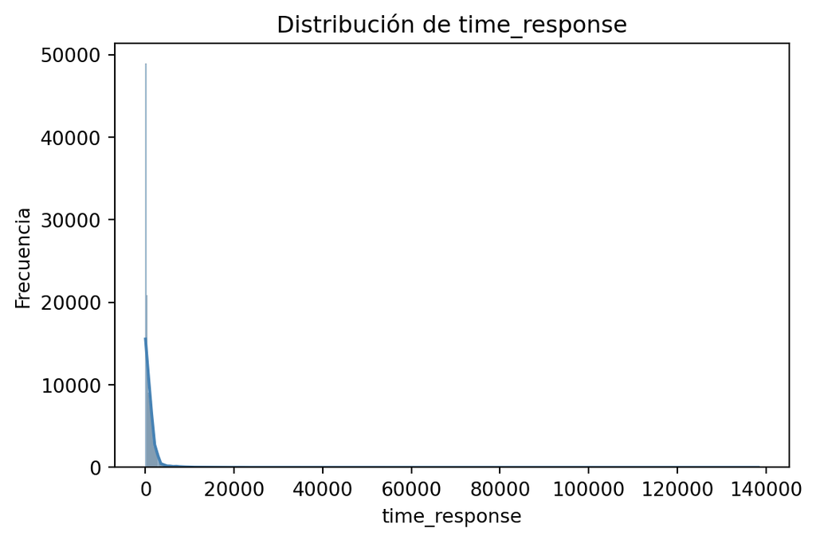

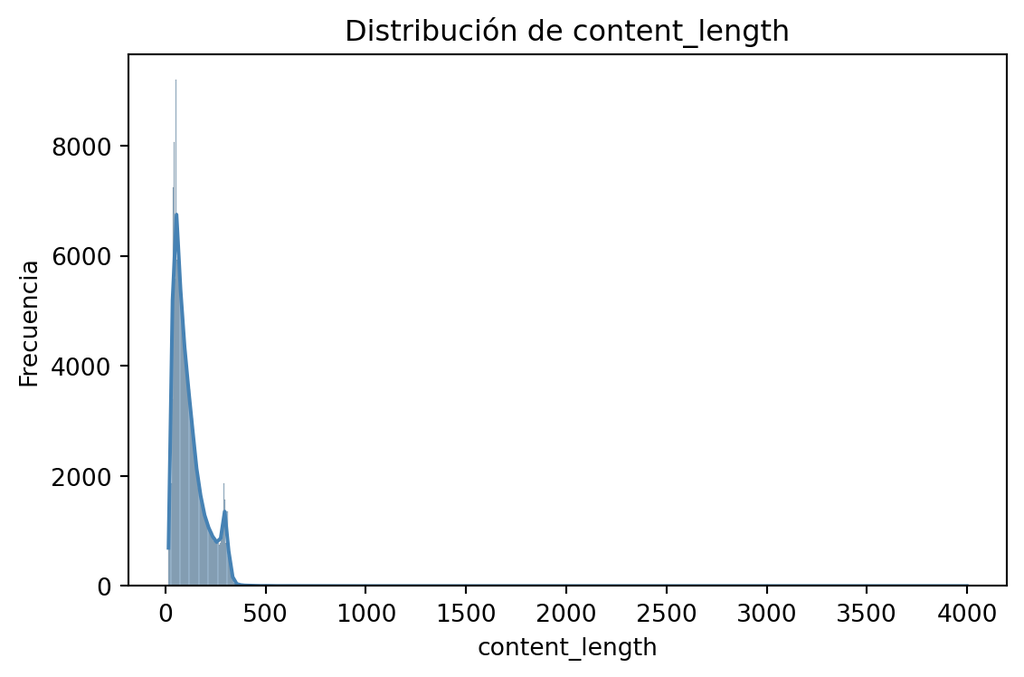

```python
# Seleccionar variables numéricas
num_cols = ['account_age_days', 'time_response', 'content_length']

# Crear histogramas para cada variable numérica
for col in num_cols:
    plt.figure(figsize=(6,4))
    sns.histplot(df[col], kde=True, color='steelblue', edgecolor='black')
    plt.title(f'Distribución de {col}')
    plt.xlabel(col)
    plt.ylabel('Frecuencia')
    plt.tight_layout()
    plt.show()
```

## Modelo

```python
# === Variables predictoras y target ===
X = df[['isReply', 'has_profile_picture', 'account_age_days',
        'time_response', 'content_length']]
y = df['bot_label']

# === División entrenamiento / prueba ===
X_train, X_test, y_train, y_test = train_test_split(
    X, y, test_size=0.25, random_state=42, stratify=y
)
```

```python
# === Preprocesamiento ===
num_cols = ['account_age_days', 'time_response', 'content_length']
cat_cols = ['isReply', 'has_profile_picture']

preprocessor = ColumnTransformer([
    ('num', StandardScaler(), num_cols),
    ('cat', OneHotEncoder(drop='if_binary'), cat_cols)
])

# === Pipeline con modelo RandomForest ===
model = Pipeline([
    ('pre', preprocessor),
    ('clf', RandomForestClassifier(
        n_estimators=200,
        random_state=42,
        class_weight='balanced'
    ))
])
```

```python
# === Entrenamiento ===
model.fit(X_train, y_train)
```

```
Pipeline(steps=[('pre',
                 ColumnTransformer(transformers=[('num', StandardScaler(),
                                                  ['account_age_days',
                                                   'time_response',
                                                   'content_length']),
                                                 ('cat',
                                                  OneHotEncoder(drop='if_binary'),
                                                  ['isReply',
                                                   'has_profile_picture'])])),
                ('clf',
                 RandomForestClassifier(class_weight='balanced',
                                        n_estimators=200, random_state=42))])
```

```python
# === Predicciones ===
y_pred = model.predict(X_test)
```

```python
# === Evaluación ===
print("=== Reporte de Clasificación ===")
print(classification_report(y_test, y_pred, digits=3))
```

```
=== Reporte de Clasificación ===
              precision    recall  f1-score   support

           0      1.000     1.000     1.000     34178
           1      1.000     1.000     1.000      5541

    accuracy                          1.000     39719
   macro avg      1.000     1.000     1.000     39719
weighted avg      1.000     1.000     1.000     39719
```

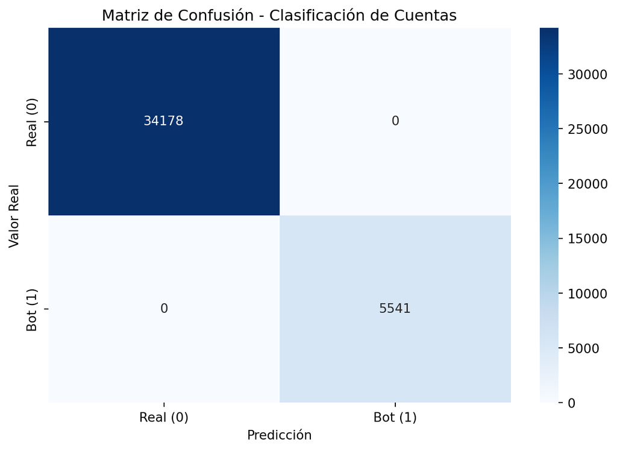

```python
# === Matriz de confusión ===
cm = confusion_matrix(y_test, y_pred)
sns.heatmap(cm, annot=True, fmt='d', cmap='Blues',
            xticklabels=['Real (0)', 'Bot (1)'],
            yticklabels=['Real (0)', 'Bot (1)'])
plt.title('Matriz de Confusión - Clasificación de Cuentas')
plt.xlabel('Predicción')
plt.ylabel('Valor Real')
plt.tight_layout()
plt.show()
```